# Simulate Admixed Populations with `bnpsd`

## Customizing the allele frequency and genotype pipeline

The random variables generated by `draw_all_admix` above can also be generated separately using the following functions (where $p$ is the usual variable symbol for allele frequencies):

- `draw_p_anc` (drawn ancestral allele frequencies)
- `draw_p_subpops` (draw independent subpopulation allele frequencies)
- `make_p_ind_admix` (construct individual-specific allele frequencies under the admixture model)
- `draw_genotypes_admix` (draw genotypes under the admixture model)

These functions are provided for greater flexibility (examples follow further below). However, the joint function `draw_all_admix` has the advantage of removing fixed loci (loci that were randomly set to 0 or 2 for all individuals, despite non-zero allele frequencies), which are re-drawn from scratch (starting from the ancestral allele frequencies).

Here is the step-by-step procedure for drawing AFs and genotypes in the default `draw_all_admix` (except for the re-drawing of fixed loci):

```r
# reuse the previous m_loci, inbr_subpops, admix_proportions
# draw ancestral AFs
p_anc <- draw_p_anc(m_loci)
# draw intermediate independent subpopulations AFs
p_subpops <- draw_p_subpops(p_anc, inbr_subpops)
# draw individual-specific AFs
p_ind <- make_p_ind_admix(p_subpops, admix_proportions)
# draw genotypes
X <- draw_genotypes_admix(p_ind)
```

We provide functions for these separate steps to allow for more flexibility. It is worth noting that `draw_p_anc` can be used to draw from a Symmetric Beta distribution if the `beta` parameter is set. In the example below, a small shape value of `beta` $< 1$ is used to draw a distribution with more rare minor variants.

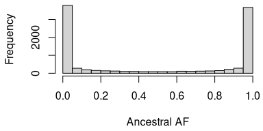

```r
# this increases the proportion of rare alleles
p_anc_beta <- draw_p_anc(m_loci, beta = 0.1)
# shrink default margins for these figures
par(mar = c(4, 4, 0, 0) + 0.2)
hist(p_anc_beta, xlab = 'Ancestral AF', main = '', xlim = c(0, 1))
```

However, if you want any other distribution, that can be implemented at this step. For a ridiculous example, the ancestral allele frequencies could be drawn from a (non-symmetric) Beta instead of using `draw_p_anc`:

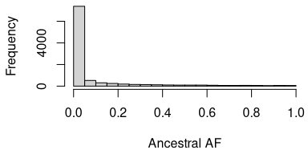

```r
# this increases the proportion of rare alleles
p_anc_beta <- rbeta(m_loci, shape1 = 0.1, shape2 = 1)
# shrink default margins for these figures
par(mar = c(4, 4, 0, 0) + 0.2)
hist(p_anc_beta, xlab = 'Ancestral AF', main = '', xlim = c(0, 1))
```

You could also draw genotypes from the ancestral population or the intermediate populations:

```r
# draw genotypes for one individual from the ancestral population
# use "cbind" to turn the vector p_anc into a column matrix
# ("draw_genotypes_admix" expects a matrix)
X_anc <- draw_genotypes_admix( cbind( p_anc ) )
# returns a column matrix:
dim(X_anc)
```

```
#> [1] 10000     1
```

```r
# draw genotypes from intermediate populations
# draws one individual per intermediate population
X_subpops <- draw_genotypes_admix(p_subpops)
```

# Additional population structures

Here we show examples for functions that create admixture matrices for various simple population structures. The admixture scenarios implemented in `bnpsd` are generated by these functions:

- `admix_prop_1d_linear`: Linear 1D geography
- `admix_prop_1d_circular`: Circular 1D geography
- `admix_prop_indep_subpops`: Independent Subpopulations

The main example (above) was for `admix_prop_1d_linear`, the rest follow.

## Circular 1D geography

This is a twist on the earlier 1D geography where subpopulations and individuals are placed on a circumference, so random walks wrap around and the appropriate density is the Von Misses distribution.

Let’s generate an analogous population structure to the original “linear” example.

```r
# data dimensions
# number of individuals
n_ind <- 100
# number of intermediate subpops
k_subpops <- 10

# define population structure
# subpopulation FST vector, up to a scalar
inbr_subpops <- 1 : k_subpops
# desired bias coefficient
bias_coeff <- 0.5
# desired FST for the admixed individuals
Fst <- 0.1

# admixture proportions from *circular* 1D geography
obj <- admix_prop_1d_circular(
    n_ind = n_ind,
    k_subpops = k_subpops,
    bias_coeff = bias_coeff,
    coanc_subpops = inbr_subpops,
    fst = Fst
)
admix_proportions <- obj$admix_proportions
inbr_subpops <- obj$coanc_subpops

# get pop structure parameters of the admixed individuals
coancestry <- coanc_admix(admix_proportions, inbr_subpops)

# verify that we got the desired FST!
fst_admix(admix_proportions, inbr_subpops)
```

```
#> [1] 0.1
```

```r
# verify that we got the desired bias_coeff too!
mean(coancestry) / Fst
```

```
#> [1] 0.5
```

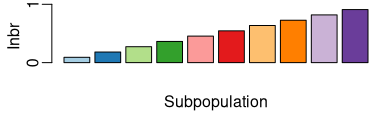

```r
# visualize the per-subpopulation inbreeding coefficients (FSTs)
# tweak margins/etc
par(mar = c(2.5, 2.5, 0.3, 0) + 0.2, lab = c(2, 1, 7), mgp = c(1.5, 0.5, 0))
# colors for independent subpopulations
col_subpops <- brewer.pal(k_subpops, "Paired")
barplot(inbr_subpops, col = col_subpops, names.arg = colnames(admix_proportions), xlab = 'Subpopulation', ylab = 'Inbr')
```

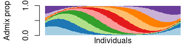

```r
# visualize the admixture proportions
# tweak margins/etc
par(mar = c(1, 4, 0.4, 0) + 0.2, lab = c(2, 2, 7))
barplot(
    t(admix_proportions),
    col = col_subpops,
    border = NA,
    space = 0,
    ylab = 'Admix prop'
)
mtext('Individuals', 1)
```

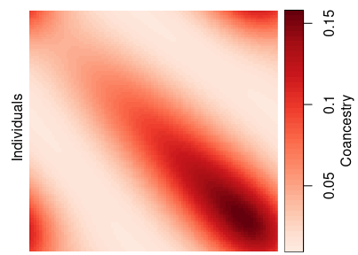

```r
# Visualize the coancestry matrix using "popkin"!
plot_popkin(
    coancestry,
    leg_n = 3,
    mar = c(0, 0.4),
    leg_title = 'Coancestry'
)
```

## Independent subpopulations

The independent subpopulations model, where individuals are actually unadmixed, is the most trivial form of the BN-PSD admixture model.

```r
# define population structure
# we'll have k_subpops = 3, each subpopulation with these sizes:
n1 <- 100
n2 <- 50
n3 <- 20

# here's the labels (for simplicity, list all individuals of S1 first, then S2, then S3)
labs <- c(
    rep.int('S1', n1),
    rep.int('S2', n2),
    rep.int('S3', n3)
)
# data dimensions infered from labs:

# number of individuals "n_ind"
length(labs)
```

```
#> [1] 170
```

```r
# number of subpopulations "k_subpops"
k_subpops <- length(unique(labs))
k_subpops
```

```
#> [1] 3
```

```r
# desired admixture matrix
admix_proportions <- admix_prop_indep_subpops(labs)

# got a numeric matrix with a single 1 value per row
# (denoting the sole subpopulation from which each individual draws its ancestry)
head(admix_proportions, 2)
```

```
#>      S1 S2 S3
#> [1,]  1  0  0
#> [2,]  1  0  0
```

```r
# construct the intermediate subpopulation FST vector
# the desired final FST
Fst <- 0.2
# subpopulation FST vector, unnormalized so far
inbr_subpops <- 1 : k_subpops
# normalized to have the desired FST
# NOTE fst is a function in the `popkin` package
inbr_subpops <- inbr_subpops / fst(inbr_subpops) * Fst
# verify FST for the intermediate subpopulations
fst(inbr_subpops)
```

```
#> [1] 0.2
```

```r
# get coancestry of the admixed individuals
coancestry <- coanc_admix(admix_proportions, inbr_subpops)
# before getting FST for individuals, weigh then inversely proportional to subpop sizes
weights <- weights_subpops(labs) # function from `popkin` package
# verify FST for individuals (same as for intermediate subpops for this pop structure)
fst_admix(admix_proportions, inbr_subpops, weights)
```

```
#> [1] 0.2
```

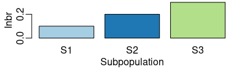

```r
# visualize the per-subpopulation inbreeding coefficients (FSTs)
# tweak margins/etc
par(mar = c(2.5, 2.5, 0, 0) + 0.2, lab = c(2, 1, 7), mgp = c(1.5, 0.5, 0))
# colors for independent subpopulations
col_subpops <- brewer.pal(k_subpops, "Paired")
barplot(inbr_subpops, col = col_subpops, names.arg = colnames(admix_proportions), xlab = 'Subpopulation', ylab = 'Inbr')
```

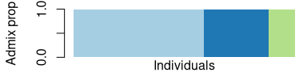

```r
# visualize the admixture proportions
# tweak margins/etc
par(mar = c(1, 4, 0.4, 0) + 0.2, lab = c(2, 2, 7))
barplot(
    t(admix_proportions),
    col = col_subpops,
    border = NA,
    space = 0,
    ylab = 'Admix prop'
)
mtext('Individuals', 1)
```

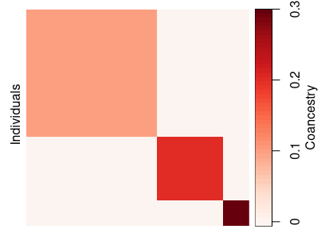

```r
# Visualize the coancestry matrix using "popkin"!
plot_popkin(
    coancestry,
    leg_n = 3,
    mar = c(0, 0.4),
    leg_title = 'Coancestry'
)
```

## Intermediate subpopulations related by a tree

In all of the previous examples we simulated from **independent** subpopulations first, then admixed individuals in various ways (1D linear and 1D circular scenarios, as well as “independent subpopulations” which meant there was no admixture). Here we use an extension of the approach to simulate the intermediate subpopulations related by a **tree**, which allows for **correlated** subpopulations.

First let’s construct the tree of interest. An easy-to-understand example is a serial founder effect, where there are consecutive splits on one branch, which somewhat resembles the human tree. For simplicity we model only 5 “tip” subpopulations and shall assume that there is equal inbreeding on every branch, equal to 0.1. This tree, in the standard (Newick) character format, is:

```r
tree_str <- '(S1:0.1,(S2:0.1,(S3:0.1,(S4:0.1,S5:0.1)N3:0.1)N2:0.1)N1:0.1)T;'
```

The tips (leaf nodes) are labeled as S1 to S5, the root node is labeled as T, and the (internal) nodes are N1 to N3. Before proceeding, we parse and process this tree using the `read.tree` function from the package `ape`, which creates the desired tree object of class `phylo` that the our functions require.

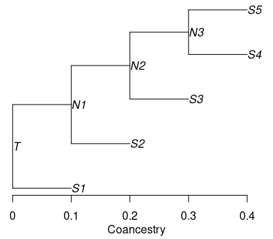

```r
# base package for phylogenetics
library(ape)
# parses tree, creates object of class "phylo"
tree_subpops <- read.tree( text = tree_str )
# plot tree
par( mar = c(3,0,0,0) + 0.2 )
plot( tree_subpops, show.node.label = TRUE )
# add axis and label
axisPhylo( backward = FALSE )
mtext( 'Coancestry', side = 1, line = 2 )
```

The values of the edges in this tree are taken to be inbreeding values, and we draw allele frequencies for each subpopulation sequentially from its parent population using the Balding-Nichols distribution, which is achieved with the function `draw_p_subpops_tree`:

```r
p_subpops_tree <- draw_p_subpops_tree(
    p_anc = p_anc,
    tree_subpops = tree_subpops
)
```

Let’s validate the correlation structure of these allele frequencies:

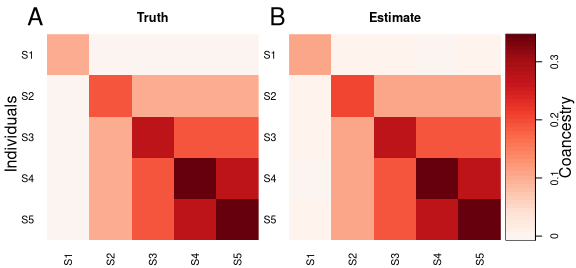

```r
# estimate coancestry
coancestry_subpops_tree_estimate <- popkin_af( p_subpops_tree )
# expected coancestry according to model
coancestry_subpops_tree <- coanc_tree( tree_subpops )
# plot
plot_popkin(
    list( coancestry_subpops_tree, coancestry_subpops_tree_estimate ),
    titles = c('Truth', 'Estimate'),
    mar = c(2, 2.5),
    leg_title = 'Coancestry',
    names = TRUE
)
```

Note that the coancestry values in the tree are not additive in the final coancestry matrix. While the tree edges go up to 0.4 (0.1 added 4 times), the maximum coancestry (equal to the total self-coancestry for node `S5` relative to `T`) is actually equal to:

```r
1 - (1 - 0.1)^4
```

```
#> [1] 0.3439
```

The discrepancy is that the coancestry values in the matrix are all relative to the root node `T`, while the edges in the plot of the tree are each relative to their parent node (the edge `N3`-`S5` is relative to `N3`). The coancestry between a pair of different subpopulations is given by the total coancestry of the most recent common ancestor node of the two subpopulations (so the coancestry of `S4` and `S5` is the self-coancestry of `N3`).

### Admixture with intermediate tree structure

```r
# number of admixed individuals
n_ind <- 100
# number of subpopulations, extracted from true coancestry
k_subpops <- nrow( coancestry_subpops_tree )

# define population structure
# for simplicity here we set spread parameter `sigma` directly
# admixture proportions from 1D geography
admix_proportions <- admix_prop_1d_linear(
    n_ind = n_ind,
    k_subpops = k_subpops,
    sigma = 0.5
)

# get pop structure parameters of the admixed individuals
coancestry <- coanc_admix(admix_proportions, coancestry_subpops_tree)

# calculate true FST of simulation
fst_admix(admix_proportions, coancestry_subpops_tree)
```

```
#> [1] 0.2078772
```

These admixture proportions resemble our previous simulation, except we reduced the number of intermediate subpopulations and the spread parameter `sigma` was picked manually just above:

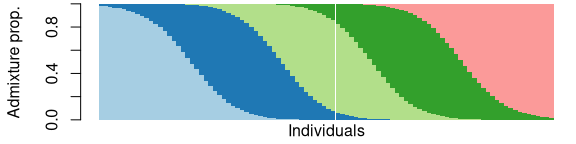

```r
# visualize the admixture proportions
# colors for these independent subpopulations
col_subpops <- brewer.pal(k_subpops, "Paired")
# shrink default margins
par(mar = c(1, 4, 0, 0) + 0.2)
barplot(
    t(admix_proportions),
    col = col_subpops,
    border = NA,
    space = 0,
    ylab = 'Admixture prop.'
)
mtext('Individuals', 1)
```

The coancestry matrix looks a bit more blocky because there are fewer intermediate subpopulations and there is less spread, and also resembles the coancestry of the tree subpopulations we visualized earlier:

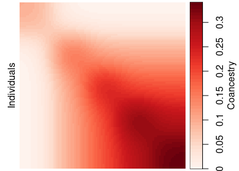

```r
# Visualize the coancestry matrix using "popkin"!
plot_popkin(
    coancestry,
    # zero inner margin (plus padding) because we have no labels
    mar = 0,
    leg_title = 'Coancestry'
)
```

### Draw random allele frequencies and genotypes for admixture with intermediate tree structure

The function `draw_all_admix` accepts `tree_subpops` in place of `inbr_subpops` to perform the entire simulation of genotypes and intermediate quantities for intermediate subpopulations related by a tree. However, unlike functions for the true structure (like `coanc_admix` and `fst_admix` earlier) which accept arbitrary intermediate coancestry matrices, the functions for drawing intermediate subpopulation allele frequencies requires trees or vectors (independent subpopulations) and do not support arbitrary coancestry matrices.

For simplicity we ask for genotypes only and skip analyzing the other allele frequency matrices (`p_subpops` here is simulated from `draw_p_subpops_tree`, which we analyzed earlier).

```r
# number of loci in simulation (NOTE this is 30x less than in publication!)
m_loci <- 10000
# draw all random Allele Freqs (AFs) and genotypes
# reuse the previous inbr_subpops, admix_proportions
out <- draw_all_admix(
    admix_proportions = admix_proportions,
    tree_subpops = tree_subpops,
    m_loci = m_loci
)
# genotypes
X <- out$X
```

Let’s verify that the correlation structure of the genotypes matches the theoretical coancestry matrix we constructed earlier.

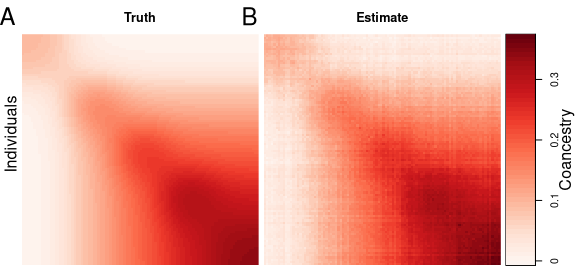

```r
# estimate kinship using popkin
# here we didn't use subpopulation labels for simplicity
kinship_estimate <- popkin(X)
# replace diagonal with inbreeding coeffs. to match coancestry matrix
coancestry_estimate <- inbr_diag(kinship_estimate)

# Visualize the coancestry matrix using "popkin"!
plot_popkin(
    list( coancestry, coancestry_estimate ),
    titles = c('Truth', 'Estimate'),
    # second value is top margin, for panel titles
    mar = c(0, 2.5),
    leg_title = 'Coancestry'
)
```

# References

Balding, D. J., and R. A. Nichols. 1995. “A Method for Quantifying Differentiation Between Populations at Multi-Allelic Loci and Its Implications for Investigating Identity and Paternity.” *Genetica* 96 (1-2): 3–12.

Ochoa, Alejandro, and John D. Storey. 2016. “FST and Kinship for Arbitrary Population Structures I: Generalized Definitions.” *bioRxiv* doi:10.1101/083915. https://doi.org/10.1101/083915.

———. 2021. “Estimating FST and Kinship for Arbitrary Population Structures.” *PLoS Genet* 17 (1): e1009241. https://doi.org/10.1371/journal.pgen.1009241.

Pritchard, J. K., M. Stephens, and P. Donnelly. 2000. “Inference of Population Structure Using Multilocus Genotype Data.” *Genetics* 155 (2): 945–59.